# Higher Education Market Segmentation

Eric Skuse

6/15/2020

```r
library(tidyverse)
```

```r
library(ggplot2)
library(ggthemes)
```

```r
library(readxl)
IPEDsColleges <- read_excel("~/Documents/GitHub/Segmentation/Data/IPEDsColleges.xlsx")
```

## Data Prep

Here it was necessary to add in a column for the region of the US each college is located in. To this you can create a vector called st.reg with state names in one column and their associated regions in the other. Then use left join to add the st.reg data to your data set.

It was also useful to add in new columns that represent changes in the values of each variable from one year to the next.

```r
colnames(IPEDsColleges)<-c("id","name","state","type","UG2018","UG2017","apps2018","apps2017","admitrate2018","admitrate2017","yield2018","yield2017","gradrate2018","gradrate2017","instateprice2019","instateprice2018","outstateprice2019","outstateprice2018")

ipeds <- IPEDsColleges

st.reg <- data.frame(state = state.name, region = state.region)
st.reg <- rbind(st.reg, data.frame(state="District of Columbia", region="South"))

ipeds <- ipeds%>%
  left_join(st.reg , by="state")
ipeds$UGchange <- ipeds$UG2018-ipeds$UG2017
ipeds$appschange <- ipeds$apps2018-ipeds$apps2017
ipeds$admitratechange <- ipeds$admitrate2018-ipeds$admitrate2017
ipeds$yieldchange <- ipeds$yield2018-ipeds$yield2017
ipeds$gradratechange <- ipeds$gradrate2018-ipeds$gradrate2017

head(ipeds)
```

```
## # A tibble: 6 x 24
##       id name  state type  UG2018 UG2017 apps2018 apps2017 admitrate2018
##    <dbl> <chr> <chr> <chr>  <dbl>  <dbl>    <dbl>    <dbl>         <dbl>
## 1 177834 A T … Miss… Priv…      0      0       NA       NA            NA
## 2 180203 Aani… Mont… Publ…    351    282       NA       NA            NA
## 3 222178 Abil… Texas Priv…   3714   3806    11569    10252            57
## 4 138558 Abra… Geor… Publ…   6347   4012     2389     1927            69
## 5 451079 Acad… Flor… Priv…      0      0       NA       NA            NA
## 6 457271 Acad… Cali… Priv…      0      0       NA       NA            NA
## # … with 15 more variables: admitrate2017 <dbl>, yield2018 <dbl>,
## #   yield2017 <dbl>, gradrate2018 <dbl>, gradrate2017 <dbl>,
## #   instateprice2019 <dbl>, instateprice2018 <dbl>, outstateprice2019 <dbl>,
## #   outstateprice2018 <dbl>, region <fct>, UGchange <dbl>, appschange <dbl>,
## #   admitratechange <dbl>, yieldchange <dbl>, gradratechange <dbl>
```

## Applications and Yield

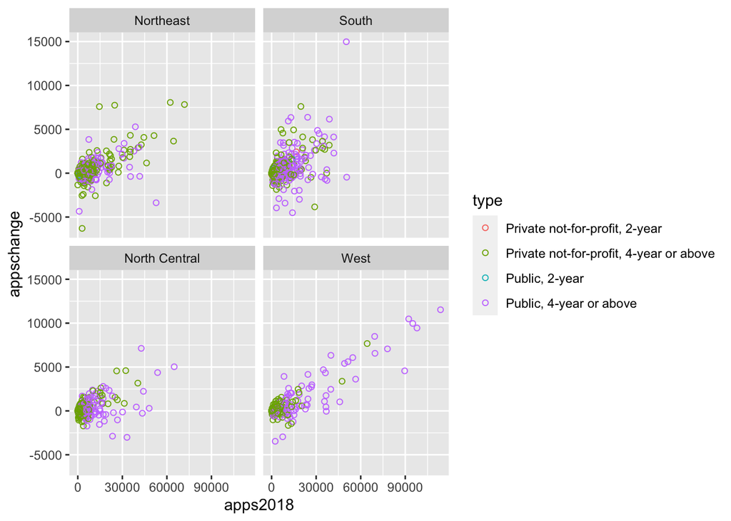

```r
ipeds%>%
  ggplot(aes(x=apps2018,y=appschange, col=type))+
  geom_point(shape=1)+
  facet_wrap(~region)
```

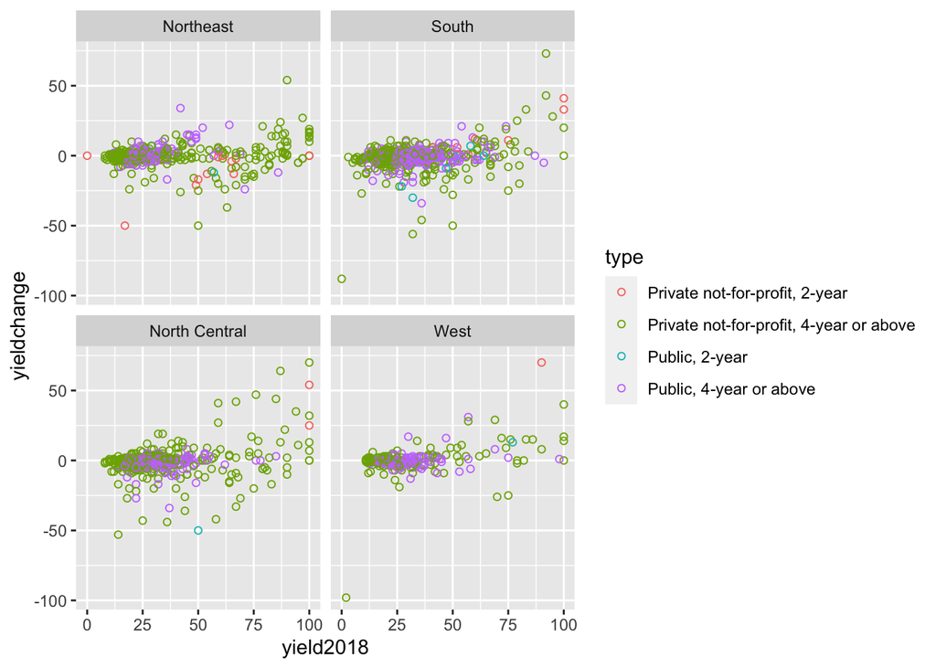

```r
ipeds%>%
  ggplot(aes(x=yield2018,y=yieldchange, col=type))+
  geom_point(shape=1)+
  facet_wrap(~region)
```

When calculating the proportion of schools that have falling application numbers in each region, the breakdown is as follows:

190/534 South segment = 36% 73/215 West = 34% 165/432 North Central = 38% 220/494 Northeast = 44%

```r
ipeds%>%
  filter(appschange<0)%>%
  filter(region=="Northeast")
```

```
## # A tibble: 220 x 24
##        id name  state type  UG2018 UG2017 apps2018 apps2017 admitrate2018
##     <dbl> <chr> <chr> <chr>  <dbl>  <dbl>    <dbl>    <dbl>         <dbl>
##  1 210571 Albr… Penn… Priv…   2111   2433     6755     8332            62
##  2 188678 Amer… New … Priv…    346    327      338      379            84
##  3 188942 Asso… New … Priv…    145    152       67       79            97
##  4 164562 Assu… Mass… Priv…   2167   2318     4178     4576            81
##  5 164580 Babs… Mass… Priv…   2669   2354     6383     7122            24
##  6 167792 Bard… Mass… Priv…    432    402      281      348            81
##  7 164720 Beck… Mass… Priv…   2274   2652     3916     4972            66
##  8 444413 Beis… New … Priv…    127    115       55       70            76
##  9 190956 Bela… New … Priv…    144    130        2        5             0
## 10 485999 Bet … New … Priv…    139    119       33       35            91
## # … with 210 more rows, and 15 more variables: admitrate2017 <dbl>,
## #   yield2018 <dbl>, yield2017 <dbl>, gradrate2018 <dbl>, gradrate2017 <dbl>,
## #   instateprice2019 <dbl>, instateprice2018 <dbl>, outstateprice2019 <dbl>,
## #   outstateprice2018 <dbl>, region <fct>, UGchange <dbl>, appschange <dbl>,
## #   admitratechange <dbl>, yieldchange <dbl>, gradratechange <dbl>
```

```r
ipeds%>%
  filter(appschange!="NA")%>%
  filter(region=="Northeast")
```

```
## # A tibble: 494 x 24
##        id name  state type  UG2018 UG2017 apps2018 apps2017 admitrate2018
##     <dbl> <chr> <chr> <chr>  <dbl>  <dbl>    <dbl>    <dbl>         <dbl>
##  1 188429 Adel… New … Priv…   5819   5768    13006    11851            74
##  2 188526 Alba… New … Priv…    916    911     1985     1366            72
##  3 128498 Albe… Conn… Priv…   1519   1620     1388      933            58
##  4 210571 Albr… Penn… Priv…   2111   2433     6755     8332            62
##  5 188641 Alfr… New … Priv…   1993   2017     4296     3566            63
##  6 210669 Alle… Penn… Priv…   1859   1957     5479     5114            64
##  7 210775 Alve… Penn… Priv…   2730   2835     2628     2179            68
##  8 188678 Amer… New … Priv…    346    327      338      379            84
##  9 164447 Amer… Mass… Priv…   1425   1473     2411     1988            68
## 10 188854 Amer… New … Priv…   1722   1853    10653     9153            24
## # … with 484 more rows, and 15 more variables: admitrate2017 <dbl>,
## #   yield2018 <dbl>, yield2017 <dbl>, gradrate2018 <dbl>, gradrate2017 <dbl>,
## #   instateprice2019 <dbl>, instateprice2018 <dbl>, outstateprice2019 <dbl>,
## #   outstateprice2018 <dbl>, region <fct>, UGchange <dbl>, appschange <dbl>,
## #   admitratechange <dbl>, yieldchange <dbl>, gradratechange <dbl>
```